# Schweizerische Wasserkraft

[Zu Homepage zurückkehren](https://mathiassteilen.github.io/)

[Zu Data Visualisation Posts zurückkehren](https://mathiassteilen.github.io/dataviz.html)

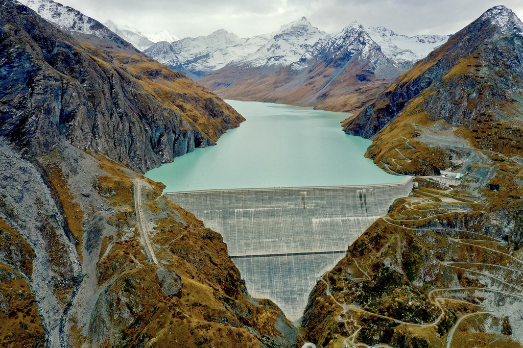

Bildquelle: Jérémy Toma/Wikimedia

### Beschreibung der Daten

Die [Daten zur Schweizer Wasserkraft](https://opendata.swiss/de/dataset/statistik-der-wasserkraftanlagen-wasta) stammen vom Schweizer Bundesamt für Energie und wurden von Swiss Open Data abgerufen. Vier Dateien enthalten Informationen zu den Namen, dem Standort, dem Alter, dem Typ und den Spezifikationen der Wasserkraftanlagen. Der [zweite Datensatz über den Füllstand der Wasserreservoirs](https://opendata.swiss/de/dataset/fullungsgrad-der-speicherseen-sonntag-24h-wochenbericht-speicherinhalt/resource/0418060b-adef-483d-afc7-bff668cc2759) stammt ebenfalls vom BFE und wurde ebenfalls über Open Data bezogen.

### Datenaufbereitung

Nachdem ich die vier verschiedenen Dateien der ersten Datengrundlage eingelesen habe, verbinde ich die Informationen mit der Haupttabelle per left-join und verwerfe unnötige Informationen. Was bleibt, sind alle nützlichen Informationen:

```r
data <- plants %>%
  left_join(plant_type %>% transmute(id, type = de),
            by = c("type_code" = "id")) %>%
  left_join(plant_specs,
            by = c("wasta_number" = "hydropower_plant_r")) %>%
  left_join(plant_status %>% transmute(id, status = de),
            by = c("operational_status_code" = "id")) %>%
  select(-c(type_code, type_code, xtf_id, operational_status_code))

glimpse(data)
```

```
## Rows: 718
## Columns: 16
## $ wasta_number                  <dbl> 100100, 100125, 100150, 100200, 100250, …
## $ name                          <chr> "Val Giuv", "Curnera Druckminderer", "Va…
## $ location                      <chr> "Rueras", "Schiebekammer Curnera Sataum.…
## $ canton                        <chr> "GR", "GR", "GR", "GR", "GR", "GR", "GR"…
## $ beginning_of_operation        <dbl> 1979, 2021, 1945, 1968, 1968, 1962, 1947…
## $ x                             <dbl> 2700400, 2697758, 2701420, 2701770, 2701…
## $ y                             <dbl> 1169740, 1165697, 1170140, 1169620, 1169…
## $ type                          <chr> "Laufkraftwerk", "Laufkraftwerk", "Laufk…
## $ year                          <dbl> 2021, 2021, 2021, 2021, 2021, 2021, 2021…
## $ performance_generator_maximum <dbl> 1.42, 2.10, 2.00, 147.00, 0.70, 176.40, …
## $ performance_turbine_maximum   <dbl> 1.50, 2.10, 2.00, 150.00, 0.75, 180.00, …
## $ production_expected           <dbl> 6.10, 10.00, 6.00, 258.40, 2.90, 563.40,…
## $ pumps_power_input_maximum     <dbl> 0, 0, 0, 0, 0, 0, 0, 0, 0, 0, 0, 0, 0, 0…
## $ engine_power_demand           <dbl> 0.0, 0.0, 0.0, 0.0, 0.0, 0.0, 0.0, 0.0, …
## $ date_of_statistic             <chr> "31/12/2021", "31/12/2021", "31/12/2021"…
## $ status                        <chr> "im Normalbetrieb", "im Normalbetrieb", …
```

Glücklicherweise gibt es praktisch keine fehlenden Werte, mit Ausnahme der Spalte `canton`, in der nur etwa 2% der Daten fehlen.

```r
colMeans(is.na(data)) %>%
  enframe() %>%
  rename(missing = value) %>%
  filter(missing > 0)
```

| name | missing |
| --- | --- |
| canton | 0.02089136 |

Mit den bereinigten Daten kann ich die Fragen, an denen ich interessiert bin, visuell untersuchen.

### Welche Kantone haben die höchste erwartete Produktion?

Wallis und Graubünden sind die beiden wichtigsten Kantone für Speicherkraftwerke und Pumpspeicherkraftwerke. Aargau ist ebenfalls noch ein wichtiger Kanton im Bezug auf Lauftkraftwerke. Laufkraftwerke erzeugen in Erwartung jedoch noch mehr als Speicherkraftwerke, da sie in vielen Kantonen der Schweiz zur Anwendung kommen. Speicherkraftwerke sind konzentriert auf wenige Kantone, die durch die Höhendifferenzen der Alpen begünstigt sind.

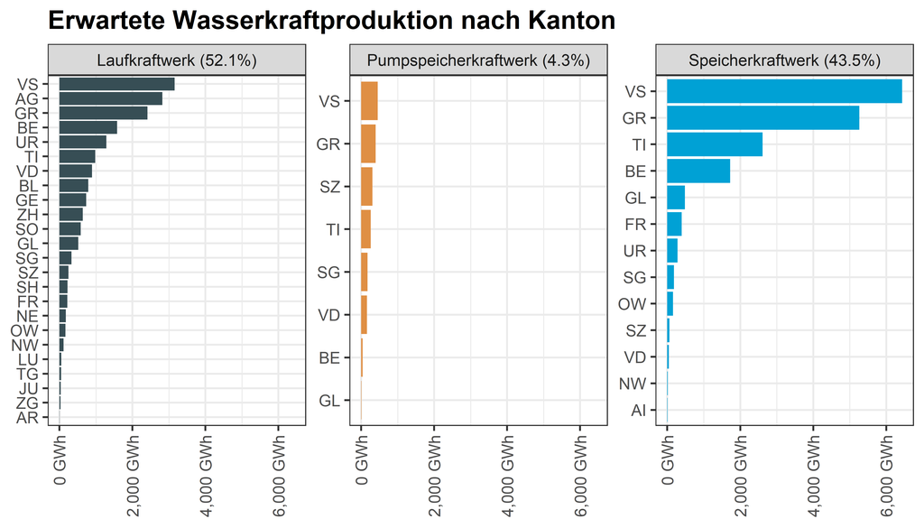

```r
data %>%
  filter(type != "reines Umwälzwerk",
         type != "reines Umw\u00e4lzwerk",
         !is.na(canton)) %>%
  left_join(data %>%
              group_by(type) %>%
              summarise(gwh = sum(production_expected)) %>%
              mutate(share = gwh/sum(gwh)) %>%
              select(type, share),
            by = "type") %>%
  mutate(type = paste0(type, " (", percent(share), ")")) %>%
  group_by(canton, type) %>%
  summarise(gwh = sum(production_expected)) %>%
  ungroup() %>%
  ggplot(aes(x = gwh,
             y = canton %>% reorder_within(gwh, type),
             fill = type)) +
  geom_col() +
  facet_wrap(~ type, scales = "free_y") +
  labs(title = "Erwartete Wasserkraftproduktion nach Kanton",
       y = NULL,
       x = NULL,
       fill = NULL) +
  scale_y_reordered() +
  scale_x_continuous(labels = comma_format(suffix = " GWh")) +
  ggsci::scale_fill_jama() +
  theme(axis.text.x = element_text(angle = 90, hjust = 1, vjust = 0.5),
        legend.position = "none")
```

### Welche Kantone haben die höchste erwartete Produktion (Karte)?

Für diese Visualisierung ziehe ich [Basisgeometriedaten des Bundesamts für Statistik](https://www.bfs.admin.ch/bfs/en/home/services/geostat/swiss-federal-statistics-geodata/administrative-boundaries/generalized-boundaries-local-regional-authorities.html) zur Hilfe. Da diese Kantonsnummern und ausgeschriebene Namen statt Kürzeln verwenden, left-joine ich die Kantonsnummern inklusive Produktionswerten ebenfalls auf die Geodaten, um ein Choroplethendiagramm zu ermöglichen.

```r
swiss_cantons <- swiss_cantons %>%
  left_join(
    data %>%
      filter(!is.na(canton)) %>%
      group_by(canton) %>%
      summarise(production = sum(production_expected)) %>%
      mutate(KTNR = case_when(canton == "ZH" ~ 1,
                              canton == "BE" ~ 2,
                              canton == "LU" ~ 3,
                              canton == "UR" ~ 4,
                              canton == "SZ" ~ 5,
                              canton == "OW" ~ 6,
                              canton == "NW" ~ 7,
                              canton == "GL" ~ 8,
                              canton == "ZG" ~ 9,
                              canton == "FR" ~ 10,
                              canton == "SO" ~ 11,
                              canton == "BS" ~ 12,
                              canton == "BL" ~ 13,
                              canton == "SH" ~ 14,
                              canton == "AR" ~ 15,
                              canton == "AI" ~ 16,
                              canton == "SG" ~ 17,
                              canton == "GR" ~ 18,
                              canton == "AG" ~ 19,
                              canton == "TG" ~ 20,
                              canton == "TI" ~ 21,
                              canton == "VD" ~ 22,
                              canton == "VS" ~ 23,
                              canton == "NE" ~ 24,
                              canton == "GE" ~ 25,
                              canton == "JU" ~ 26)),
    by = "KTNR")
```

Wie bereits vom Barchart im ersten Abschnitt gelernt, sind Wallis und Graubünden besonders wichtig für die Wasserkraft in der Schweiz durch ihre Speicherkraftwerke. Dies wird im nachfolgenden Diagramm besonders ersichtlich:

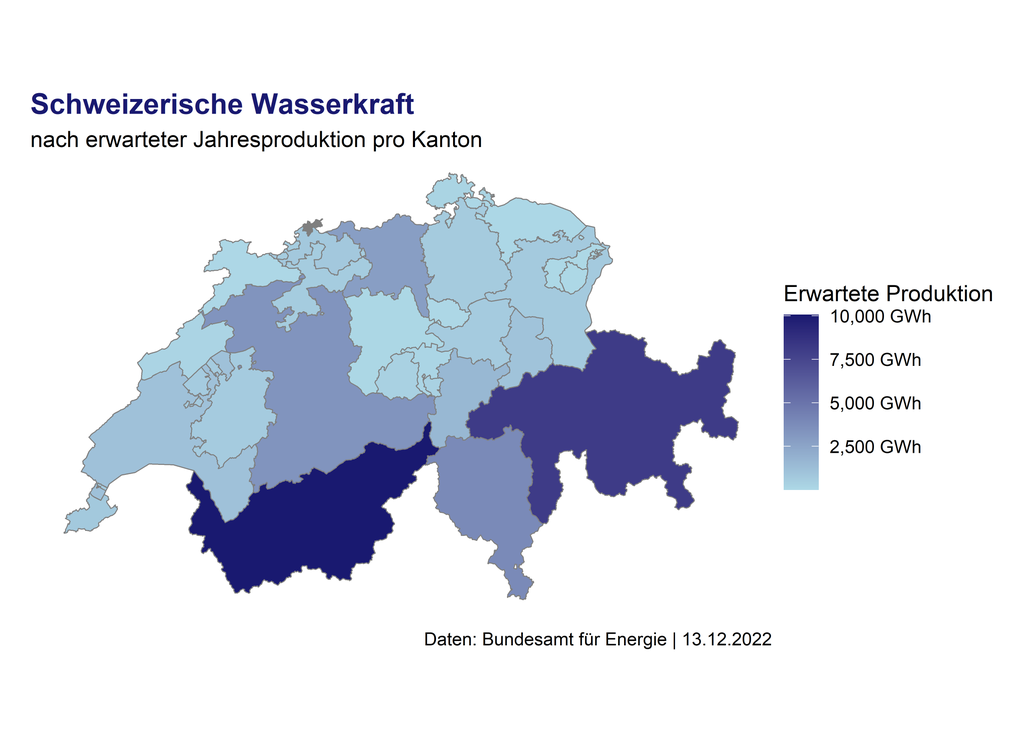

```r
ggplot() +
  geom_sf(data = swiss_cantons, aes(fill = production), colour = "grey50",
          size = 0.25) +
  labs(title = "Schweizerische Wasserkraft",
       subtitle = "nach erwarteter Jahresproduktion pro Kanton",
       caption = "Daten: Bundesamt für Energie | 13.12.2022",
       fill = "Erwartete Produktion") +
  scale_fill_continuous(labels = comma_format(suffix = " GWh"),
                        type = "gradient", low = "lightblue",
                        high = "midnightblue") +
  theme_void() +
  theme(legend.position = "right",
        plot.title = element_text(colour = "midnightblue", face = "bold",
                                  size = 14),
        plot.margin = margin(5, 15, 5, 15))
```

### Die Lage der Kraftwerke in der Schweiz

Da Längen- und Breitengrade der Kraftwerke in den Daten verfügbar sind, kann ich nun ebenfalls die genaue Lage der Kraftwerke abbilden. Ebenfalls vermerkt sind die erwartete jährliche Produktion in Gigawattstunden und der Typ des Kraftwerks. Die graue Schattierung der Kantone ist vergleichbar mit dem Diagramm zuvor und indiziert die erwartete Gesamtproduktion in einem Jahr. Das besonders grosse Speicherkraftwerk im Wallis ist der Grande Dixence Damm, mit der höchsten Gewichtsstaumauer der Welt - die sechsthöchste Staumauer insgesamt und die höchste Staumauer in Europa. Die erwartete jährliche Produktion des Kraftwerks von über 2,000 GWh reicht, um 400,000 Haushalte in der Schweiz zu versorgen.

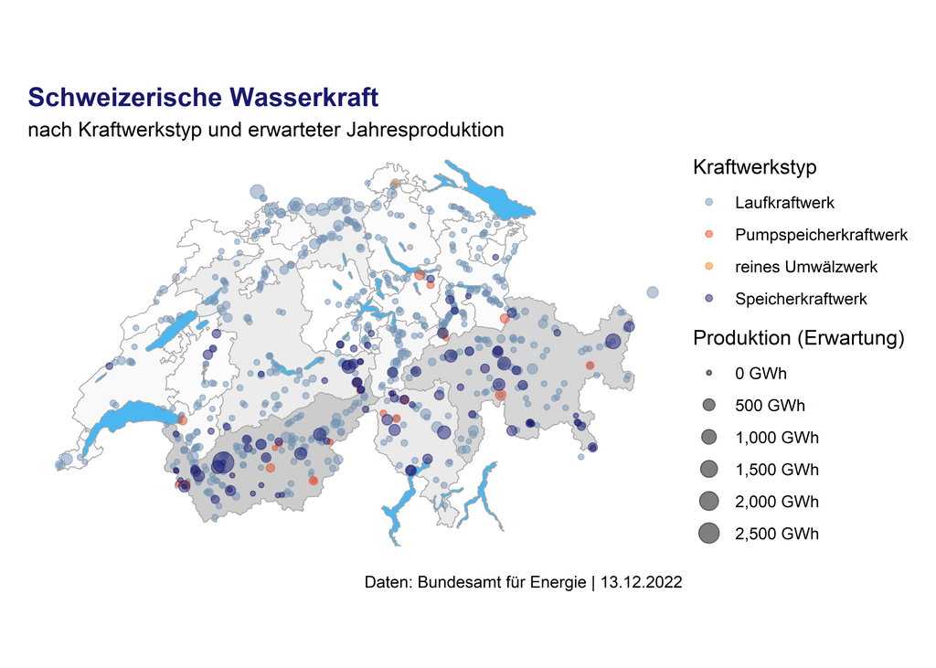

```r
ggplot() +
  geom_sf(data = swiss_cantons, aes(fill = production),
          colour = "grey65", alpha = 0.2, size = 0.25) +
  geom_sf(data = swiss_lakes, fill = "#4BB6EF",
          colour = "grey65", size = 0.25) +
  geom_point(data = data %>% arrange(type),
             aes(x = x, y = y, colour = type, size = production_expected),
             alpha = 0.5) +
  labs(title = "Schweizerische Wasserkraft",
       subtitle = "nach Kraftwerkstyp und erwarteter Jahresproduktion",
       caption = "Daten: Bundesamt für Energie | 13.12.2022",
       colour = "Kraftwerkstyp",
       size = "Produktion (Erwartung)") +
  guides(fill = "none") +
  scale_colour_manual(values = c("#7393B3", "#E14D2A",
                                 "#FD841F", "midnightblue")) +
  theme_void() +
  scale_fill_continuous(labels = comma_format(suffix = " GWh"),
                        type = "gradient", low = "white",
                        high = "black") +
  scale_size_continuous(labels = comma_format(suffix = " GWh"),
                        range = c(1, 5)) +
  theme(legend.position = "right",
        plot.title = element_text(colour = "midnightblue", face = "bold",
                                  size = 14),
        plot.margin = margin(5, 15, 5, 15))
```

### Füllstand der Speicherseen

Mit der zweiten Datei des BFE kann ich die Verläufe der Pegelstände in den Stauseen visualisieren. Die Daten spannen von 2000 bis 2022. 2000 bis 2021 verwende ich, um empirische Konfidenzbänder zu erstellen, während 2022 als Linie über diese Bänder zum Vergleich gezogen wird. Aus der untenstehenden Graphik wird ersichtlich, dass die Speicherseen deutlichen Zulauf in den Sommermonaten haben, und/oder Wasser in die Seen pumpen, und Wasser ablassen, also Energie generieren, über die kälteren Wintermonate. Dies ist sowohl zuträglich für die Handelsergebnisse der Energieversorger, aber auch für die Konsumenten, da die hohe Nachfrage nach Elektrizität im Winter durch die Wasserkraft gestützt werden kann. Das Jahr 2022 hat die Medianlinie mehrfach durchschritten und sitzt aktuell über dem 90sten Perzentil des Füllungsgrad. Sofern diese Niveaus beibehalten werden, wird diese einer möglichen Mangellage im fortschreitenden Winter positiv entgegenwirken können.

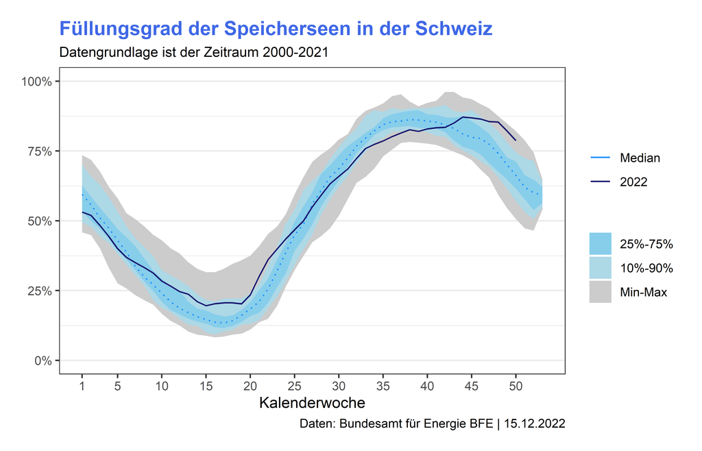

```r
reservoirs %>%
  filter(year(datum) < 2022) %>%
  group_by(week) %>%
  summarise(quantile = c("zero", "ten", "twentyfive", "fifty", "seventyfive",
                         "ninety", "hundred"),
            pct_fill = quantile(pct_fill, c(0, 0.1, 0.25, 0.5, 0.75, 0.9, 1),
                                na.rm = T)) %>%
  pivot_wider(names_from = quantile, values_from = pct_fill) %>%
  ggplot(aes(x = week)) +
  # Q25 - Q75
  geom_ribbon(aes(ymin = twentyfive, ymax = seventyfive, fill = "25%-75%")) +
  # Q10 - Q90
  geom_ribbon(aes(ymin = seventyfive, ymax = ninety, fill = "10%-90%")) +
  geom_ribbon(aes(ymin = ten, ymax = twentyfive, fill = "10%-90%")) +
  # Min Max
  geom_ribbon(aes(ymin = zero, ymax = ten, fill = "Min-Max")) +
  geom_ribbon(aes(ymin = ninety, ymax = hundred, fill = "Min-Max")) +
  # Median Line
  geom_line(aes(y = fifty, colour = "Median"), lty = "dotted") +
  # Line for 2022
  geom_line(data = reservoirs %>% filter(year(datum) == 2022),
            aes(x = week, y = pct_fill, colour = "2022")) +
  scale_fill_manual(values = c("25%-75%" = "#87CEEB",
                               "10%-90%" = "#ADD8E6",
                               "Min-Max" = "#CCCCCC")) +
  scale_colour_manual(values = c("Median" = "dodgerblue",
                                 "2022" = "midnightblue")) +
  labs(title = "Füllungsgrad der Speicherseen in der Schweiz",
       subtitle = "Datengrundlage ist der Zeitraum 2000-2021",
       caption = "Daten: Bundesamt für Energie BFE | 15.12.2022",
       y = NULL, x = "Kalenderwoche",
       fill = NULL, colour = NULL) +
  scale_x_continuous(breaks = c(1, seq(5, 52, 5))) +
  scale_y_continuous(labels = percent_format(), limits = c(0, 1)) +
  theme(plot.title = element_text(colour = "#3F68E6", size = 14),
        plot.subtitle = element_text(colour = "black", face = "plain",
                                     size = 10),
        panel.grid.major.x = element_blank(),
        panel.grid.minor.x = element_blank(),
        plot.margin = margin(15, 15, 15, 15))
```

Ich hoffe, dieser Artikel war interessant. Falls Sie konstruktives Feedback teilen oder sich über dieses oder ein verwandtes Thema austauschen möchten, können Sie mich gerne über die verlinkten sozialen Netzwerke kontaktieren. Vielen Dank fürs Lesen.

A work by [Mathias Steilen](https://www.linkedin.com/in/mathias-steilen/)